# Análisis descriptivo

Simón Pedro Galeano Muñoz

# Construcción de la base de datos

En primer lugar, cabe mencionar que se tomo una base de datos de la plataforma [Datos Abiertos Colombia](https://www.datos.gov.co/), más específicamente la base de datos [Casos positivos de Covid-19 en el departamento de Antioquia](https://www.datos.gov.co/Salud-y-Protecci-n-Social/Casos-positivos-de-Covid-19-en-el-departamento-de-/w3du-c2j6).

Dicha base de datos se compone de 30 columnas (ver diccionario de la base de datos) que contienen información acerca de los casos positivos que se han detectado en el departamento de Antioquia, como por ejemplo la fecha de notificación, el municipio de residencia del infectado, la fecha de recuperación, entre otras. Se deja un breve vistazo al diccionario de la base de datos.

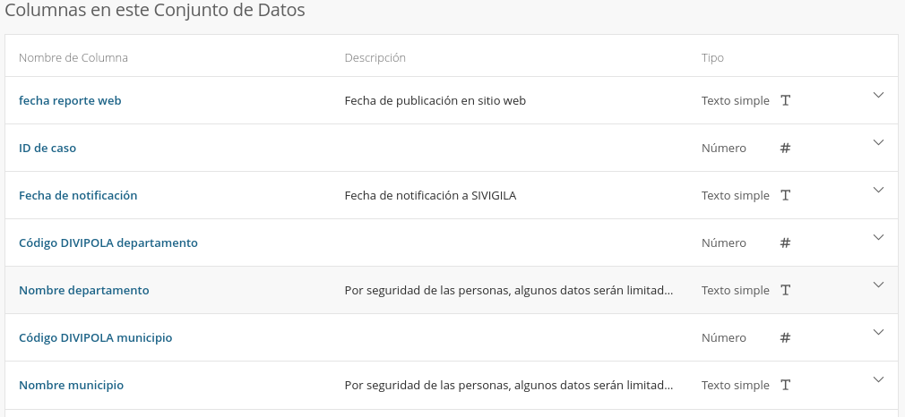

Sin embargo, dicha base no servía para la modelación, puesto que cada registro representa un paciente, así que hubo que agrupar por mes, año y municipio, para así contar el total de casos mensuales discriminando por municipio. Además de eso, se crearon variables que indicaran si se estaba en periodo de cuarentena obligatori, si ya había iniciado la vacunación si era una época post vacaciones, etc.

```r
# loading libraries
library(tidyverse)
library(magrittr)
library(lubridate)

# reading original data
datos <- read.csv("./Casos_positivos_de_Covid-19_en_el_departamento_de_Antioquia.csv") # nolint

area <- c(
  "MEDELLIN", "ITAGUI", "BELLO", "GIRARDOTA", "CALDAS",
  "ENVIGADO", "SABANETA", "LA ESTRELLA", "COPACABANA", "BARBOSA"
) # metropolitan area municiples # nolint
# cleaning data
datos %<>%
  select(Fecha.de.recuperación, Nombre.municipio, Recuperado, Fecha.de.muerte) %>% # nolint selecting necessary variables to build the data base for modelling
  mutate(
    Fecha.de.recuperación = str_extract(Fecha.de.recuperación, "\\d+-\\d+-\\d+"), # nolint
    Fecha.de.recuperación = as.Date(Fecha.de.recuperación), # formatting dates
    Fecha.de.muerte = str_extract(Fecha.de.muerte, "\\d+-\\d+-\\d+"),
    Fecha.de.muerte = as.Date(Fecha.de.muerte), # formatting dates
    Recuperado = if_else(Recuperado == "fallecido", "Fallecido", Recuperado)
  ) %>% # properly formatting data # nolint
  filter(Recuperado %in% c("Recuperado", "Fallecido")) %>%
  mutate(
    Fecha = if_else(Recuperado == "Recuperado", Fecha.de.recuperación, Fecha.de.muerte), # nolint
    Mes = month(Fecha), Anio = year(Fecha)
  ) %>% # creating proper date variable # nolint
  select(Mes, Anio, Recuperado, Nombre.municipio) %>%
  filter(Nombre.municipio %in% area) %>%
  arrange(Mes, Anio)

final_data <- datos %>%
  group_by(Anio, Mes, Nombre.municipio) %>%
  summarise(
    Recuperados = sum(Recuperado != "Fallecido"),
    Cuarentena = if_else(Anio > 2020, "No", if_else(Mes >= 10, "No", "Si")), # nolint
    Vacunacion = if_else(Anio == 2020, "No", if_else(Mes >= 2, "Si", "No")),
    Post_vacaciones = if_else(Mes %in% c(7, 1), "Si", "No")
  )

final_data <- final_data[!duplicated(final_data), ]
saveRDS(final_data, "Data.Rds")
```

Se muestran algunas filas del resultado final.

| Año | Mes | Municipio | Recuperados | Cuarentena | Vacunación | Post vacaciones |
| --- | --- | --- | --- | --- | --- | --- |
| 2020 | 3 | BELLO | 2 | Si | No | No |
| 2020 | 3 | ENVIGADO | 1 | Si | No | No |
| 2020 | 3 | ITAGUI | 1 | Si | No | No |
| 2020 | 3 | MEDELLIN | 28 | Si | No | No |
| 2020 | 3 | SABANETA | 2 | Si | No | No |
| 2020 | 4 | BELLO | 20 | Si | No | No |

# Gráficos descriptivos

En los siguientes gráficos el propósito es entender el comportamiento de las variables y descubrir como estas pueden ayudar en el proceso de modelación.

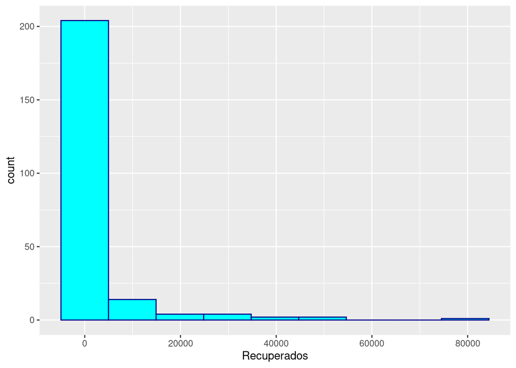

Ahora, se intenta observar si la cantidad de recuperados año a año es variable o no, para saber si considerarla en el modelo.

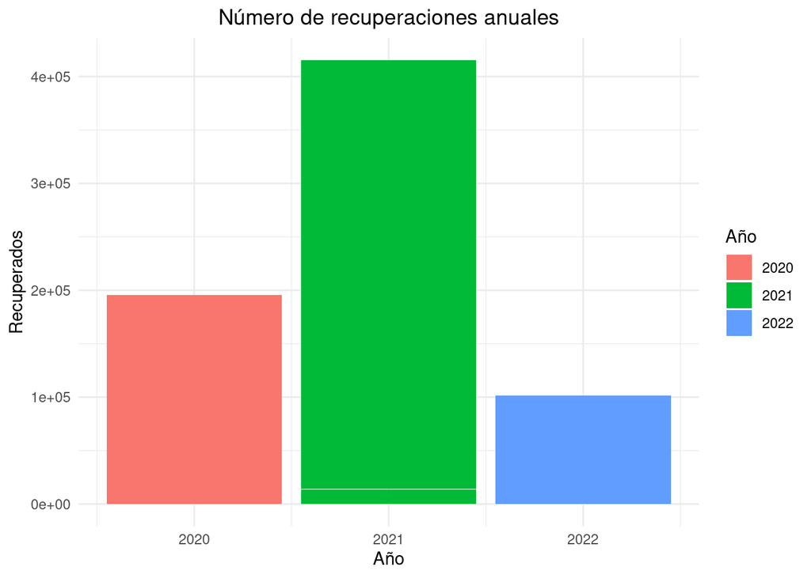

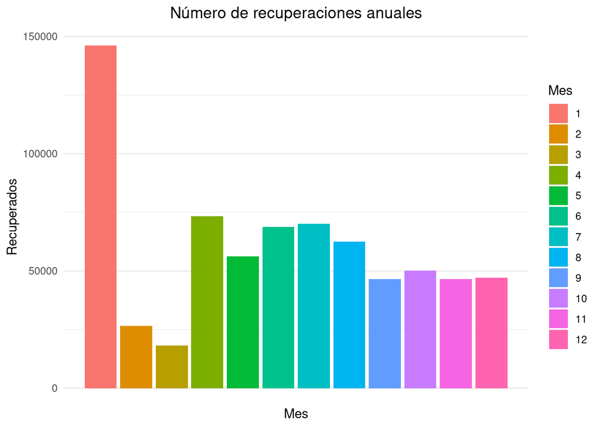

Observe ahora que la cantidad de personas recuperadas en los distintos meses difiere lo cual sugiere que esta covariable es importante para el proceso de modelación. El mes 1 (enero) es aquel en el que se presenta mayor número de recuperaciones mientras que los 2 y 3 (febrero y marzo) son los que menos recuperaciones hay, además, se puede notar que a mitad de año hay cierta tendencia creciente, por lo que es buena idea incluir una variable que indique si se está en una época inmediatamente posterior a las típicas épocas de vacaciones (diciembre y junio).

Ahora, una duda natural surge de si habrá diferencia entre municipios, en efecto.

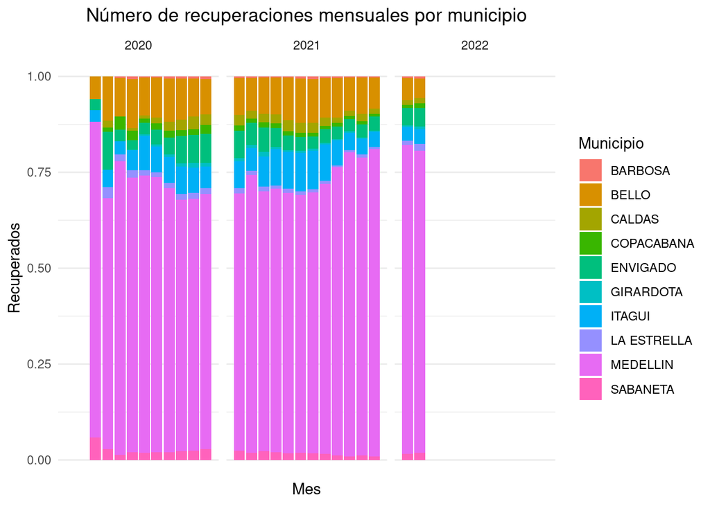

Del gráfico anterior se puede observar que hay una diferencia del número de recuperados mes a mes, también se puede apreciar que Medellín presenta comportamientos anómalos respecto al resto de municipios.

Por último resulta natural pensar que tanto la cuarentena como el inicio de la vacunación represetnan un cambio en el número de infectados y por tanto en el número de recuperados, así que se incluyen en la modelación.

# Modelos a considerar y construcción de los modelos

En esta sección se presentan los modelos considerados para la explicación del fenómeno en cuestión. Hay que tener en cuenta que $y$ hace referencia a la cantidad de recuperados, $i$ al municipio y $j$ al mes.

## Modelo nulo

$$\begin{equation*}
\begin{split}
y_{ij} &\sim \text{Poisson}(\lambda_{ij}) \\
log(\lambda_{ij}) &= \beta_0 + b_{0i} \\
b_0 &\sim N(0, \sigma_{b_0}^2)
\end{split}
\end{equation*}$$

```r
modnull <- glmer(Recuperados ~ 1 + (1 | Nombre.municipio),
  data = datos, family = poisson()) # nolint
```

## Modelo 1

$$\begin{equation*}
\begin{split}
y_{ij} &\sim \text{Poisson}(\lambda_{ij}) \\
log(\lambda_{ij}) &= \beta_0 + \beta_1 \times \text{Año}_{ij} + b_{0i} \\
b_0 &\sim N(0, \sigma_{b_0}^2)
\end{split}
\end{equation*}$$

```r
modone <- glmer(Recuperados ~  Anio + (1 | Nombre.municipio),
  data = datos, family = poisson()) # nolint
```

## Modelo 2

$$\begin{equation*}
\begin{split}
y_{ij} &\sim \text{Poisson}(\lambda_{ij}) \\
log(\lambda_{ij}) &= \beta_0 + \beta_1 \times \text{Año}_{ij} + \beta_2 \times \text{Mes}_{i} + b_{0i} \\
b_0 &\sim N(0, \sigma_{b_0}^2)
\end{split}
\end{equation*}$$

```r
modtwo <- glmer(Recuperados ~ Anio + Mes + (1 | Nombre.municipio),
  data = datos, family = poisson()) # nolint
```

## Modelo 3

$$\begin{equation*}
\begin{split}
y_{ij} &\sim \text{Poisson}(\lambda_{ij}) \\
log(\lambda_{ij}) &= \beta_0 + \beta_1 \times \text{Año}_{ij} + \beta_2 \times \text{Mes}_{i} + b_{0i} + b_{1i} \times \text{Mes}_{i} \\
[b_0 \ b_1]^T &\sim N(\underline{\mathbf{0}}, \Sigma_1)
\end{split}
\end{equation*}$$

donde
$$\Sigma_1 = \begin{bmatrix}
\sigma_{b_0}^2 \ \sigma_{b_{01}} \\
\sigma_{b_{01}} \ \sigma_{b_1}^2
\end{bmatrix}$$

```r
modthree <- glmer(Recuperados ~ Anio + Mes + (Mes | Nombre.municipio),
  data = datos, family = poisson()) # nolint
```

## Modelo 4

$$\begin{equation*}
\begin{split}
y_{ij} &\sim \text{Poisson}(\lambda_{ij}) \\
log(\lambda_{ij}) &= \beta_0 + \beta_1 \times \text{Año}_{ij} + \beta_2 \times \text{Mes}_{i} + \beta_3 \times \text{VacunacionSi}_{ij} + b_{0i} + b_{1i} \times \text{Mes}_{i} \\
[b_0 \ b_1]^T &\sim N(\underline{\mathbf{0}}, \Sigma_1)
\end{split}
\end{equation*}$$

donde
$$\Sigma_1 = \begin{bmatrix}
\sigma_{b_0}^2 \ \sigma_{b_{01}} \\
\sigma_{b_{01}} \ \sigma_{b_1}^2
\end{bmatrix}$$

```r
modfour <- glmer(Recuperados ~ Anio + Mes + Vacunacion + (Mes | Nombre.municipio), #nolint
  data = datos, family = poisson()) # nolint
```

## Modelo 5

$$\begin{equation*}
\begin{split}
y_{ij} &\sim \text{Poisson}(\lambda_{ij}) \\
log(\lambda_{ij}) &= \beta_0 + \beta_1 \times \text{Año}_{ij} + \beta_2 \times \text{Mes}_{i} + \beta_3 \times \text{VacunacionSi}_{ij} + \beta_4 \times \text{CuarentenaSi}_{ij} + \beta_5 \times \text{Post_vacacionesSi}_{ij} + b_{0i} + b_{1i} \times \text{Mes}_{i} + b_{2i} \times \text{Cuarentena}_{ij} \\
[b_0 \ b_1 \ b_2]^T &\sim N(\underline{\mathbf{0}}, \Sigma_2)
\end{split}
\end{equation*}$$

donde
$$\Sigma_2 = \begin{bmatrix}
\sigma_{b_0}^2 \ \sigma_{b_{01}} \ \sigma_{b_{02}} \\
\sigma_{b_{01}} \sigma_{b_1}^2 \ \sigma_{b_{12}} \\
\sigma_{b_{02}} \sigma_{b_{12}} \ \sigma_{b_{2}}^2
\end{bmatrix}$$

```r
modfive <- glmer(Recuperados ~ Anio + Mes + Vacunacion + Cuarentena + Post_vacaciones + (Cuarentena + Mes | Nombre.municipio), #nolint
  data = datos, family = poisson()) # nolint
```

# Comparación de modelos

Finalmente, se presenta una comparación sucesiva entre modelos a través de pruebas de razón de verosimilitud

```
## Data: datos
## Models:
## modnull: Recuperados ~ 1 + (1 | Nombre.municipio)
## modone: Recuperados ~ Anio + (1 | Nombre.municipio)
## modtwo: Recuperados ~ Anio + Mes + (1 | Nombre.municipio)
## modthree: Recuperados ~ Anio + Mes + (Mes | Nombre.municipio)
## modfour: Recuperados ~ Anio + Mes + Vacunacion + (Mes | Nombre.municipio)
## modfive: Recuperados ~ Anio + Mes + Vacunacion + Cuarentena + Post_vacaciones + (Cuarentena + Mes | Nombre.municipio)
##          npar    AIC    BIC  logLik deviance     Chisq Df Pr(>Chisq)
## modnull     2 633269 633276 -316633   633265
## modone      3 563552 563562 -281773   563546  69719.64  1  < 2.2e-16 ***
## modtwo      4 562910 562924 -281451   562902    643.28  1  < 2.2e-16 ***
## modthree    6 561467 561487 -280727   561455   1447.71  2  < 2.2e-16 ***
## modfour     7 541431 541455 -270708   541417  20037.80  1  < 2.2e-16 ***
## modfive    12 422214 422256 -211095   422190 119226.25  5  < 2.2e-16 ***
## ---
## Signif. codes:  0 '***' 0.001 '**' 0.01 '*' 0.05 '.' 0.1 ' ' 1
```

De allí se puede observar que claramente el mejor modelo es el modelo número 5.

# Análisis de residuales

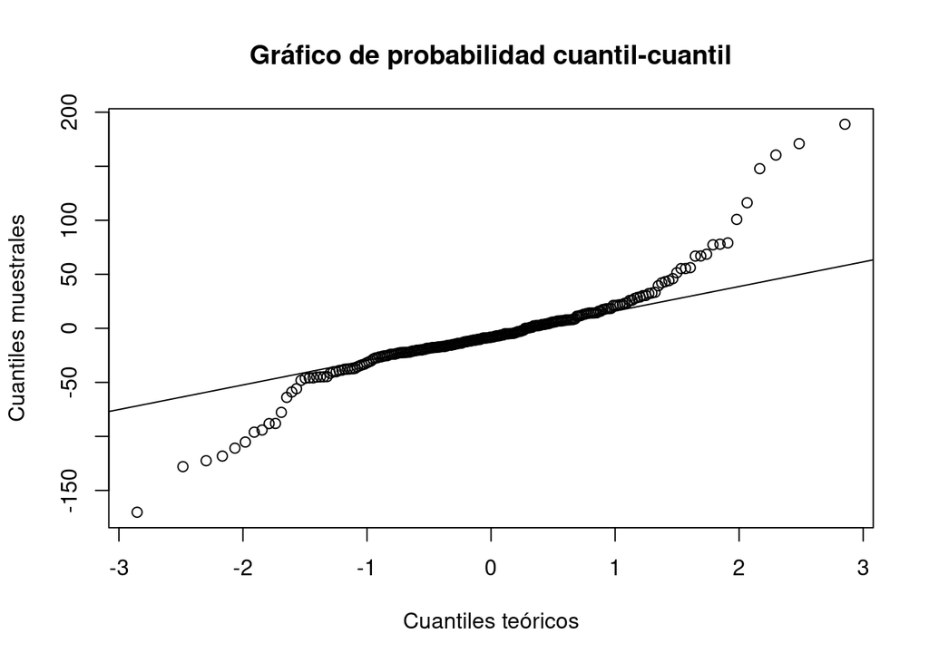

# Presentacion del mejor modelo